# purrr updates (v1.0.0)

### `purrr` progress bars

I’ll use `walk2()` below and add `.progress = TRUE` to view the `purrr` progress bar (and `quiet = TRUE` to silence the `download.file()` progress bar).

**show/hide**

```r
walk2(.x = nyt_file_urls, .y = nyt_local_pths, .f =  download.file,
      .progress = TRUE, quiet = TRUE)
```

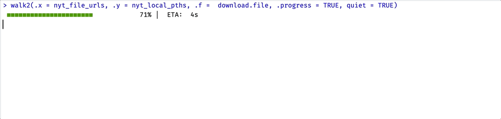

I can confirm the download using `fs::dir_tree()`

**show/hide**

```r
fs::dir_tree("dds-nyt")
## dds-nyt
## ├── nyt10.csv
## ├── nyt11.csv
## ├── nyt12.csv
## ├── nyt13.csv
## ├── nyt7.csv
## ├── nyt8.csv
## └── nyt9.csv
```

## Copying a directory of files

> *You have a folder of files you’d like to rename or copy to a new directory*

The collection of 7 .csv files from [Doing Data Science](https://github.com/oreillymedia/doing_data_science) by Cathy O’Neil and Rachel Schutt (O’Reilly Media) are now in the `dds-nyt/` folder.

As with any project, I don’t want to alter the raw data, so I’m going to copy these files into `dds-nyt-raw/` and `dds-nyt-processed/`. I also want the processed file names to have a date stamp prefix.

**show/hide**

```r
file_pths <- list.files("dds-nyt", full.names = TRUE, pattern = ".csv$")
file_pths
## [1] "dds-nyt/nyt10.csv" "dds-nyt/nyt11.csv" "dds-nyt/nyt12.csv"
## [4] "dds-nyt/nyt13.csv" "dds-nyt/nyt7.csv"  "dds-nyt/nyt8.csv"
## [7] "dds-nyt/nyt9.csv"
```

I’ll start with the raw data folder. I need to create a vector of the new raw file paths and names: `raw_file_pths` (the raw data paths will have the original file names)

**show/hide**

```r
# do it for one
gsub(pattern = "^dds-nyt",
  replacement = "dds-nyt/raw",
  x = file_pths[1])
## [1] "dds-nyt/raw/nyt10.csv"

# write the recipe
file_pths |> purrr::map_chr(\(x) gsub(x,
                                pattern = "^dds-nyt",
                                replacement = "dds-nyt/raw")) |> head()
## [1] "dds-nyt/raw/nyt10.csv" "dds-nyt/raw/nyt11.csv" "dds-nyt/raw/nyt12.csv"
## [4] "dds-nyt/raw/nyt13.csv" "dds-nyt/raw/nyt7.csv"  "dds-nyt/raw/nyt8.csv"

# map it across all
raw_file_pths <- file_pths |>
                  purrr::map_chr(\(x) gsub(x,
                                        pattern = "^dds-nyt",
                                        replacement = "dds-nyt/raw"))
```

Before copying the files, I need to create the destination folder for the raw data (`dds-nyt/raw`). Then, I’ll make sure I can copy the first element from `file_pths` into the path in the first element of `raw_file_pths`:

**show/hide**

```r
fs::dir_create("dds-nyt/raw")
# do it for one
fs::file_copy(
  path = file_pths[1],
  new_path = raw_file_pths[1],
  overwrite = TRUE)
fs::dir_tree("dds-nyt/raw", type = "any")
## dds-nyt/raw
## └── nyt10.csv
```

I can see this is working, so I can use `purrr::walk2()` to move all the files from `dds-nyt/` to `dds-nyt/raw/`

**show/hide**

```r
purrr::walk2(.x = file_pths, .y = raw_file_pths, .f = fs::file_copy,
      .progress = TRUE, overwrite = TRUE)
fs::dir_tree("dds-nyt/raw", type = "any")
## dds-nyt/raw
## ├── nyt10.csv
## ├── nyt11.csv
## ├── nyt12.csv
## ├── nyt13.csv
## ├── nyt7.csv
## ├── nyt8.csv
## └── nyt9.csv
```

Now that I’ve copied the files into their respective folders, I’ll need to remove the files from their original location in the parent `dds-nyt` folder.

Fortunately, I have a vector of these files in `file_pths`, and I can test removal with `fs::file_delete()`:

**show/hide**

```r
fs::file_delete(file_pths[1])
```

Great! Now that I know this will work, I’ll use `walk()` because I want `.x` returned invisibly and the side-effect of `.f`.

But I’ve also deleted the first element in `file_pths`, so when `fs::file_delete()` goes looking for that file, it will find nothing and returned an error.

**show/hide**

```bash
Error in `map()`:
ℹ In index: 1.
Caused by error:
! [ENOENT] Failed to remove 'dds-nyt/nyt10.csv': no such file or directory
```

**show/hide**

```r
purrr:::walk(
  # list CURRENT files
    .x = list.files(
      path = "dds-nyt",
      pattern = ".csv$",
      full.names = TRUE),
    # map function
    .f = fs::file_delete)
```

And confirm the new folder contents and structure

**show/hide**

```r
fs::dir_tree("dds-nyt", type = "any", recurse = TRUE)
## dds-nyt
## └── raw
##     ├── nyt10.csv
##     ├── nyt11.csv
##     ├── nyt12.csv
##     ├── nyt13.csv
##     ├── nyt7.csv
##     ├── nyt8.csv
##     └── nyt9.csv
```

## Import multiple datasets

> *You have several days of data, and each day is contained in separate file. You’d like to read these data into R, and combine them into a single dataset*

Now that I have separate raw and processed folders, I can import the NYT data into R. Below I’ve imported a single file from the `raw` data folder to examine it’s contents:

**show/hide**

```r
nyt1 <- vroom::vroom(file = raw_file_pths[1],
  delim = ",",
  show_col_types = FALSE)
str(nyt1)
## spc_tbl_ [452,766 × 5] (S3: spec_tbl_df/tbl_df/tbl/data.frame)
##  $ Age        : num [1:452766] 59 0 19 44 30 33 41 41 0 23 ...
##  $ Gender     : num [1:452766] 1 0 0 1 1 1 0 0 0 1 ...
##  $ Impressions: num [1:452766] 4 7 5 5 4 3 1 3 9 1 ...
##  $ Clicks     : num [1:452766] 0 1 0 0 0 0 0 0 1 0 ...
##  $ Signed_In  : num [1:452766] 1 0 1 1 1 1 1 1 0 1 ...
##  - attr(*, "spec")=
##   .. cols(
##   ..   Age = col_double(),
##   ..   Gender = col_double(),
##   ..   Impressions = col_double(),
##   ..   Clicks = col_double(),
##   ..   Signed_In = col_double(),
##   ..   .delim = ","
##   .. )
##  - attr(*, "problems")=<externalptr>
```

Each `nyt` file contains daily ads shown and clicks recorded on the New York Times home page. The rows represent users, and the variables are: `Age`, `Gender` (0 = female, 1 = male), `Impressions` (number impressions), `Clicks` (number clicks), and a binary indicator for signed in or not `Signed_in`.

I’ll add some hypothetical wrangling steps to make this example more realistic.

I’ve bundled all of these steps into a function (`nyt_data_processing()`) that I can pass each dataset through:

**show/hide**

```r
nyt_data_processing <- function(nyt_csv) {
  orig_nms <- c("Age", "Gender", "Impressions", "Clicks", "Signed_In")
  nyt_nms <- names(nyt_csv)
  if (isFALSE(identical(x = orig_nms, y = nyt_nms))) {
    cli::cli_abort("these data don't have the correct columns!")
  } else {
    nyt_proc <- nyt_csv |>
      dplyr::mutate(
        # create age_group variable
        age_group = case_when(
          Age < 18 ~ "<18",
          Age >= 18 & Age < 25 ~ "18-24",
          Age >= 25 & Age < 35 ~ "25-34",
          Age >= 35 & Age < 45 ~ "35-44",
          Age >= 45 & Age < 55 ~ "45-54",
          Age >= 55 & Age < 65 ~ "55-64",
          Age >= 65 ~ "65+"
        ),
        # factor age_group (ordered)
        age_group = factor(age_group,
          levels = c(
            "<18", "18-24", "25-34",
            "35-44", "45-54", "55-64", "65+"
          ),
          ordered = TRUE
        ),
        # create CTR variable
        ctr_rate = round(x = Clicks / Impressions, digits = 3),
        # create new Female variable
        female = case_when(
          Gender == 0 ~ "yes",
          Gender == 1 ~ "no",
          TRUE ~ NA_character_
        ),
        # factor female (un-ordered)
        female = factor(female,
          levels = c("no", "yes")
        ),
        Signed_In = case_when(
          Signed_In == 0 ~ "no",
          Signed_In == 1 ~ "yes",
          TRUE ~ NA_character_),
        # factor Signed_In (un-ordered)
        Signed_In = factor(Signed_In, levels = c("no", "yes"))) |>
      # format columns
      janitor::clean_names()
  }
  return(nyt_proc)
}
```

I’ll do some quick checks to make sure it only works with the raw data columns:

**show/hide**

```r
nyt1_proc <- nyt_data_processing(nyt1)
str(nyt1_proc)
## spc_tbl_ [452,766 × 8] (S3: spec_tbl_df/tbl_df/tbl/data.frame)
##  $ age        : num [1:452766] 59 0 19 44 30 33 41 41 0 23 ...
##  $ gender     : num [1:452766] 1 0 0 1 1 1 0 0 0 1 ...
##  $ impressions: num [1:452766] 4 7 5 5 4 3 1 3 9 1 ...
##  $ clicks     : num [1:452766] 0 1 0 0 0 0 0 0 1 0 ...
##  $ signed_in  : Factor w/ 2 levels "no","yes": 2 1 2 2 2 2 2 2 1 2 ...
##  $ age_group  : Ord.factor w/ 7 levels "<18"<"18-24"<..: 6 1 2 4 3 3 4 4 1 2 ...
##  $ ctr_rate   : num [1:452766] 0 0.143 0 0 0 0 0 0 0.111 0 ...
##  $ female     : Factor w/ 2 levels "no","yes": 1 2 2 1 1 1 2 2 2 1 ...
##  - attr(*, "spec")=
##   .. cols(
##   ..   Age = col_double(),
##   ..   Gender = col_double(),
##   ..   Impressions = col_double(),
##   ..   Clicks = col_double(),
##   ..   Signed_In = col_double(),
##   ..   .delim = ","
##   .. )
##  - attr(*, "problems")=<externalptr>
```

I’ll run `nyt_data_processing()` against a processed data file (`nyt1_proc`)

**show/hide**

```r
nyt_data_processing(nyt1_proc)
## Error in `nyt_data_processing()`:
## ! these data don't have the correct columns!
```

Now I’m ready to write the import step. First I’ll store the raw file paths in `raw_data_pths`

**show/hide**

```r
raw_data_pths <- list.files(path = "dds-nyt/raw", pattern = ".csv$", full.names = TRUE)
```

We’ll test `purrr::map()` and `vroom::vroom()` to import the `.csv` files in `raw_data_pths` into a list. I also add `utils::head()` and `dplyr::glimpse()` to limit the output.

**show/hide**

```r
raw_data_pths |>
  # import
  purrr::map(
    vroom::vroom,
        delim = ",", show_col_types = FALSE) |>
  utils::head(2) |>
  dplyr::glimpse()
## List of 2
##  $ : spc_tbl_ [452,766 × 5] (S3: spec_tbl_df/tbl_df/tbl/data.frame)
##   ..$ Age        : num [1:452766] 59 0 19 44 30 33 41 41 0 23 ...
##   ..$ Gender     : num [1:452766] 1 0 0 1 1 1 0 0 0 1 ...
##   ..$ Impressions: num [1:452766] 4 7 5 5 4 3 1 3 9 1 ...
##   ..$ Clicks     : num [1:452766] 0 1 0 0 0 0 0 0 1 0 ...
##   ..$ Signed_In  : num [1:452766] 1 0 1 1 1 1 1 1 0 1 ...
##   ..- attr(*, "spec")=
##   .. .. cols(
##   .. ..   Age = col_double(),
##   .. ..   Gender = col_double(),
##   .. ..   Impressions = col_double(),
##   .. ..   Clicks = col_double(),
##   .. ..   Signed_In = col_double(),
##   .. ..   .delim = ","
##   .. .. )
##   ..- attr(*, "problems")=<externalptr>
##  $ : spc_tbl_ [478,066 × 5] (S3: spec_tbl_df/tbl_df/tbl/data.frame)
##   ..$ Age        : num [1:478066] 28 51 29 20 19 0 58 42 35 44 ...
##   ..$ Gender     : num [1:478066] 1 0 1 1 0 0 0 0 1 0 ...
##   ..$ Impressions: num [1:478066] 8 5 2 4 5 3 5 6 8 4 ...
##   ..$ Clicks     : num [1:478066] 0 0 0 0 0 1 1 0 0 0 ...
##   ..$ Signed_In  : num [1:478066] 1 1 1 1 1 0 1 1 1 1 ...
##   ..- attr(*, "spec")=
##   .. .. cols(
##   .. ..   Age = col_double(),
##   .. ..   Gender = col_double(),
##   .. ..   Impressions = col_double(),
##   .. ..   Clicks = col_double(),
##   .. ..   Signed_In = col_double(),
##   .. ..   .delim = ","
##   .. .. )
##   ..- attr(*, "problems")=<externalptr>
```

This returns a list, but you may have noticed I don’t have a great way for keeping track of the data files in the list–this is where `purrr::set_names()` comes in handy.

`purrr::set_names()` works a lot like `names()`, but `purrr::set_names()` will automatically set the names of `x` to `as.character(x)` if no names are provided to `nm`. See below:

**show/hide**

```r
raw_data_pths |> purrr::set_names()
##   dds-nyt/raw/nyt10.csv   dds-nyt/raw/nyt11.csv   dds-nyt/raw/nyt12.csv
## "dds-nyt/raw/nyt10.csv" "dds-nyt/raw/nyt11.csv" "dds-nyt/raw/nyt12.csv"
##   dds-nyt/raw/nyt13.csv    dds-nyt/raw/nyt7.csv    dds-nyt/raw/nyt8.csv
## "dds-nyt/raw/nyt13.csv"  "dds-nyt/raw/nyt7.csv"  "dds-nyt/raw/nyt8.csv"
##    dds-nyt/raw/nyt9.csv
##  "dds-nyt/raw/nyt9.csv"
```

Now the imported file will have their file path and name associated with the dataset:

**show/hide**

```r
raw_data_pths |>
  # names
  purrr::set_names() |>
  # import
    purrr::map(
      vroom::vroom,
          delim = ",", show_col_types = FALSE) |>
  utils::head(2) |>
  dplyr::glimpse()
## List of 2
##  $ dds-nyt/raw/nyt10.csv: spc_tbl_ [452,766 × 5] (S3: spec_tbl_df/tbl_df/tbl/data.frame)
##   ..$ Age        : num [1:452766] 59 0 19 44 30 33 41 41 0 23 ...
##   ..$ Gender     : num [1:452766] 1 0 0 1 1 1 0 0 0 1 ...
##   ..$ Impressions: num [1:452766] 4 7 5 5 4 3 1 3 9 1 ...
##   ..$ Clicks     : num [1:452766] 0 1 0 0 0 0 0 0 1 0 ...
##   ..$ Signed_In  : num [1:452766] 1 0 1 1 1 1 1 1 0 1 ...
##   ..- attr(*, "spec")=
##   .. .. cols(
##   .. ..   Age = col_double(),
##   .. ..   Gender = col_double(),
##   .. ..   Impressions = col_double(),
##   .. ..   Clicks = col_double(),
##   .. ..   Signed_In = col_double(),
##   .. ..   .delim = ","
##   .. .. )
##   ..- attr(*, "problems")=<externalptr>
##  $ dds-nyt/raw/nyt11.csv: spc_tbl_ [478,066 × 5] (S3: spec_tbl_df/tbl_df/tbl/data.frame)
##   ..$ Age        : num [1:478066] 28 51 29 20 19 0 58 42 35 44 ...
##   ..$ Gender     : num [1:478066] 1 0 1 1 0 0 0 0 1 0 ...
##   ..$ Impressions: num [1:478066] 8 5 2 4 5 3 5 6 8 4 ...
##   ..$ Clicks     : num [1:478066] 0 0 0 0 0 1 1 0 0 0 ...
##   ..$ Signed_In  : num [1:478066] 1 1 1 1 1 0 1 1 1 1 ...
##   ..- attr(*, "spec")=
##   .. .. cols(
##   .. ..   Age = col_double(),
##   .. ..   Gender = col_double(),
##   .. ..   Impressions = col_double(),
##   .. ..   Clicks = col_double(),
##   .. ..   Signed_In = col_double(),
##   .. ..   .delim = ","
##   .. .. )
##   ..- attr(*, "problems")=<externalptr>
```

To add the wrangling function, I can pipe in another call to `purrr::map()`, and add `nyt_data_processing()`.

**show/hide**

```r
raw_data_pths |>
  # names
  purrr::set_names() |>
  # import
    purrr::map(
      vroom::vroom,
          delim = ",", show_col_types = FALSE) |>
  # wrangle
  purrr::map(.f = nyt_data_processing) |>
  utils::head(2) |>
  dplyr::glimpse()
## List of 2
##  $ dds-nyt/raw/nyt10.csv: spc_tbl_ [452,766 × 8] (S3: spec_tbl_df/tbl_df/tbl/data.frame)
##   ..$ age        : num [1:452766] 59 0 19 44 30 33 41 41 0 23 ...
##   ..$ gender     : num [1:452766] 1 0 0 1 1 1 0 0 0 1 ...
##   ..$ impressions: num [1:452766] 4 7 5 5 4 3 1 3 9 1 ...
##   ..$ clicks     : num [1:452766] 0 1 0 0 0 0 0 0 1 0 ...
##   ..$ signed_in  : Factor w/ 2 levels "no","yes": 2 1 2 2 2 2 2 2 1 2 ...
##   ..$ age_group  : Ord.factor w/ 7 levels "<18"<"18-24"<..: 6 1 2 4 3 3 4 4 1 2 ...
##   ..$ ctr_rate   : num [1:452766] 0 0.143 0 0 0 0 0 0 0.111 0 ...
##   ..$ female     : Factor w/ 2 levels "no","yes": 1 2 2 1 1 1 2 2 2 1 ...
##   ..- attr(*, "spec")=
##   .. .. cols(
##   .. ..   Age = col_double(),
##   .. ..   Gender = col_double(),
##   .. ..   Impressions = col_double(),
##   .. ..   Clicks = col_double(),
##   .. ..   Signed_In = col_double(),
##   .. ..   .delim = ","
##   .. .. )
##   ..- attr(*, "problems")=<externalptr>
##  $ dds-nyt/raw/nyt11.csv: spc_tbl_ [478,066 × 8] (S3: spec_tbl_df/tbl_df/tbl/data.frame)
##   ..$ age        : num [1:478066] 28 51 29 20 19 0 58 42 35 44 ...
##   ..$ gender     : num [1:478066] 1 0 1 1 0 0 0 0 1 0 ...
##   ..$ impressions: num [1:478066] 8 5 2 4 5 3 5 6 8 4 ...
##   ..$ clicks     : num [1:478066] 0 0 0 0 0 1 1 0 0 0 ...
##   ..$ signed_in  : Factor w/ 2 levels "no","yes": 2 2 2 2 2 1 2 2 2 2 ...
##   ..$ age_group  : Ord.factor w/ 7 levels "<18"<"18-24"<..: 3 5 3 2 2 1 6 4 4 4 ...
##   ..$ ctr_rate   : num [1:478066] 0 0 0 0 0 0.333 0.2 0 0 0 ...
##   ..$ female     : Factor w/ 2 levels "no","yes": 1 2 1 1 2 2 2 2 1 2 ...
##   ..- attr(*, "spec")=
##   .. .. cols(
##   .. ..   Age = col_double(),
##   .. ..   Gender = col_double(),
##   .. ..   Impressions = col_double(),
##   .. ..   Clicks = col_double(),
##   .. ..   Signed_In = col_double(),
##   .. ..   .delim = ","
##   .. .. )
##   ..- attr(*, "problems")=<externalptr>
```

### `list_rbind()`

For the final step, I’ll bind all the data into a `data.frame` with the updated `purrr::list_rbind()` function (set `names_to = "id"`).

**show/hide**

```r
raw_data_pths |>
  # names
  purrr::set_names() |>
  # import
    purrr::map(
      vroom::vroom,
          delim = ",", show_col_types = FALSE) |>
  # wrangle
  purrr::map(.f = nyt_data_processing) |>
  # bind
  purrr::list_rbind(names_to = "id") |>
  dplyr::glimpse()
## Rows: 3,488,345
## Columns: 9
## $ id          <chr> "dds-nyt/raw/nyt10.csv", "dds-nyt/raw/nyt10.csv", "dds-nyt…
## $ age         <dbl> 59, 0, 19, 44, 30, 33, 41, 41, 0, 23, 28, 34, 0, 17, 33, 6…
## $ gender      <dbl> 1, 0, 0, 1, 1, 1, 0, 0, 0, 1, 1, 1, 0, 0, 1, 1, 0, 0, 0, 0…
## $ impressions <dbl> 4, 7, 5, 5, 4, 3, 1, 3, 9, 1, 4, 4, 7, 3, 7, 6, 6, 2, 7, 2…
## $ clicks      <dbl> 0, 1, 0, 0, 0, 0, 0, 0, 1, 0, 0, 0, 0, 0, 0, 0, 0, 0, 0, 0…
## $ signed_in   <fct> yes, no, yes, yes, yes, yes, yes, yes, no, yes, yes, yes, …
## $ age_group   <ord> 55-64, <18, 18-24, 35-44, 25-34, 25-34, 35-44, 35-44, <18,…
## $ ctr_rate    <dbl> 0.000, 0.143, 0.000, 0.000, 0.000, 0.000, 0.000, 0.000, 0.…
## $ female      <fct> no, yes, yes, no, no, no, yes, yes, yes, no, no, no, yes, …
```

Now that we have a complete recipe, I store the result in `nyt_data_proc`. I can also confirm all files were imported and wrangled by checking the `count()` of `id`.

**show/hide**

```r
nyt_data_proc <- raw_data_pths |>
  # names
  purrr::set_names() |>
  # import
    purrr::map(
      vroom::vroom,
          delim = ",", show_col_types = FALSE) |>
  # wrangle
  purrr::map(.f = nyt_data_processing) |>
  # bind
  purrr::list_rbind(names_to = "id")
```

**show/hide**

```r
nyt_data_proc |> dplyr::count(id)
## # A tibble: 7 × 2
##   id                         n
##   <chr>                  <int>
## 1 dds-nyt/raw/nyt10.csv 452766
## 2 dds-nyt/raw/nyt11.csv 478066
## 3 dds-nyt/raw/nyt12.csv 396308
## 4 dds-nyt/raw/nyt13.csv 786044
## 5 dds-nyt/raw/nyt7.csv  452493
## 6 dds-nyt/raw/nyt8.csv  463196
## 7 dds-nyt/raw/nyt9.csv  459472
```

## Export multiple datasets

> *You have a dataset you’d like to split into individual `data.frame`s, then export these into separate file paths*

I have a processed dataset with seven data files (`nyt_data_proc`), and I want to export these into seven processed data files in a `dds-nyt/processed/` folder.

Creating a vector of processed data file paths is a little more involved because I wanted to add a date prefix to the exported files, and because I want to add this path as a variable *in the `nyt_data_proc` dataset*.

Below I create a new `file_nm` and `proc_file_pth` column to `nyt_data_proc`:

**show/hide**

```r
# create file names
nyt_data_proc <- dplyr::mutate(.data = nyt_data_proc,
        file_nm = tools::file_path_sans_ext(base::basename(id)),
        proc_file_pth = paste0("dds-nyt/processed/",
                        as.character(Sys.Date()), "-",
                        file_nm))
nyt_data_proc |> dplyr::count(proc_file_pth)
## # A tibble: 7 × 2
##   proc_file_pth                           n
##   <chr>                               <int>
## 1 dds-nyt/processed/2023-12-16-nyt10 452766
## 2 dds-nyt/processed/2023-12-16-nyt11 478066
## 3 dds-nyt/processed/2023-12-16-nyt12 396308
## 4 dds-nyt/processed/2023-12-16-nyt13 786044
## 5 dds-nyt/processed/2023-12-16-nyt7  452493
## 6 dds-nyt/processed/2023-12-16-nyt8  463196
## 7 dds-nyt/processed/2023-12-16-nyt9  459472
```

Note that I don’t include the file extension in `proc_file_pth`, because I might want to use different file types when I’m exporting.

I’ll cover two methods for exporting datasets from a list.

In this first method, I’ll use the `base::split()` function to split `nyt_data_proc` by the `proc_file_pth` variable into a list of data frames. I’ll also use `utils::head()`, `purrr::walk()`, and `dplyr::glimpse()` to view the output.

**show/hide**

```r
split(x = nyt_data_proc, f = nyt_data_proc$proc_file_pth) |>
  utils::head(3) |>
  purrr::walk(.f = glimpse)
## Rows: 452,766
## Columns: 11
## $ id            <chr> "dds-nyt/raw/nyt10.csv", "dds-nyt/raw/nyt10.csv", "dds-n…
## $ age           <dbl> 59, 0, 19, 44, 30, 33, 41, 41, 0, 23, 28, 34, 0, 17, 33,…
## $ gender        <dbl> 1, 0, 0, 1, 1, 1, 0, 0, 0, 1, 1, 1, 0, 0, 1, 1, 0, 0, 0,…
## $ impressions   <dbl> 4, 7, 5, 5, 4, 3, 1, 3, 9, 1, 4, 4, 7, 3, 7, 6, 6, 2, 7,…
## $ clicks        <dbl> 0, 1, 0, 0, 0, 0, 0, 0, 1, 0, 0, 0, 0, 0, 0, 0, 0, 0, 0,…
## $ signed_in     <fct> yes, no, yes, yes, yes, yes, yes, yes, no, yes, yes, yes…
## $ age_group     <ord> 55-64, <18, 18-24, 35-44, 25-34, 25-34, 35-44, 35-44, <1…
## $ ctr_rate      <dbl> 0.000, 0.143, 0.000, 0.000, 0.000, 0.000, 0.000, 0.000, …
## $ female        <fct> no, yes, yes, no, no, no, yes, yes, yes, no, no, no, yes…
## $ file_nm       <chr> "nyt10", "nyt10", "nyt10", "nyt10", "nyt10", "nyt10", "n…
## $ proc_file_pth <chr> "dds-nyt/processed/2023-12-16-nyt10", "dds-nyt/processed…
## Rows: 478,066
## Columns: 11
## $ id            <chr> "dds-nyt/raw/nyt11.csv", "dds-nyt/raw/nyt11.csv", "dds-n…
## $ age           <dbl> 28, 51, 29, 20, 19, 0, 58, 42, 35, 44, 62, 20, 0, 0, 43,…
## $ gender        <dbl> 1, 0, 1, 1, 0, 0, 0, 0, 1, 0, 0, 0, 0, 0, 0, 0, 0, 0, 0,…
## $ impressions   <dbl> 8, 5, 2, 4, 5, 3, 5, 6, 8, 4, 6, 4, 5, 4, 4, 5, 3, 2, 5,…
## $ clicks        <dbl> 0, 0, 0, 0, 0, 1, 1, 0, 0, 0, 0, 0, 0, 0, 0, 0, 0, 0, 2,…
## $ signed_in     <fct> yes, yes, yes, yes, yes, no, yes, yes, yes, yes, yes, ye…
## $ age_group     <ord> 25-34, 45-54, 25-34, 18-24, 18-24, <18, 55-64, 35-44, 35…
## $ ctr_rate      <dbl> 0.000, 0.000, 0.000, 0.000, 0.000, 0.333, 0.200, 0.000, …
## $ female        <fct> no, yes, no, no, yes, yes, yes, yes, no, yes, yes, yes, …
## $ file_nm       <chr> "nyt11", "nyt11", "nyt11", "nyt11", "nyt11", "nyt11", "n…
## $ proc_file_pth <chr> "dds-nyt/processed/2023-12-16-nyt11", "dds-nyt/processed…
## Rows: 396,308
## Columns: 11
## $ id            <chr> "dds-nyt/raw/nyt12.csv", "dds-nyt/raw/nyt12.csv", "dds-n…
## $ age           <dbl> 29, 0, 27, 0, 69, 0, 0, 39, 53, 27, 0, 13, 26, 63, 79, 0…
## $ gender        <dbl> 0, 0, 0, 0, 1, 0, 0, 1, 0, 1, 0, 1, 1, 0, 1, 0, 0, 1, 1,…
## $ impressions   <dbl> 4, 1, 2, 5, 9, 1, 6, 4, 7, 3, 1, 1, 2, 5, 6, 7, 3, 1, 5,…
## $ clicks        <dbl> 1, 0, 0, 1, 1, 0, 0, 0, 0, 0, 0, 0, 0, 0, 1, 0, 0, 0, 0,…
## $ signed_in     <fct> yes, no, yes, no, yes, no, no, yes, yes, yes, no, yes, y…
## $ age_group     <ord> 25-34, <18, 25-34, <18, 65+, <18, <18, 35-44, 45-54, 25-…
## $ ctr_rate      <dbl> 0.250, 0.000, 0.000, 0.200, 0.111, 0.000, 0.000, 0.000, …
## $ female        <fct> yes, yes, yes, yes, no, yes, yes, no, yes, no, yes, no, …
## $ file_nm       <chr> "nyt12", "nyt12", "nyt12", "nyt12", "nyt12", "nyt12", "n…
## $ proc_file_pth <chr> "dds-nyt/processed/2023-12-16-nyt12", "dds-nyt/processed…
```

I can see this is returning a list of data frames as expected, so now I need to pass this list into `purrr::walk2()` so I can iterate `vroom::vroom_write()` over the processed data paths in `proc_file_pth`.

1. First I create the processed data folder (`dds-nyt/processed/`)

**show/hide**

```r
fs::dir_create("dds-nyt/processed/")
```

2. Second, I create the `.x` argument, which is the split list of `nyt_data_proc` by `proc_file_pth`

**show/hide**

```r
# split nyt_data_proc (.x)
by_proc_pths <- nyt_data_proc |>
  split(nyt_data_proc$proc_file_pth)
```

3. Third, I get the unique processed data paths in the `proc_file_pth` column and store it as a vector for the `.y`

**show/hide**

```r
# get unique processed paths in nyt_data_proc (.y) with .csv extension
proc_pths <- paste0(unique(nyt_data_proc$proc_file_pth), ".csv")
proc_pths
## [1] "dds-nyt/processed/2023-12-16-nyt10.csv"
## [2] "dds-nyt/processed/2023-12-16-nyt11.csv"
## [3] "dds-nyt/processed/2023-12-16-nyt12.csv"
## [4] "dds-nyt/processed/2023-12-16-nyt13.csv"
## [5] "dds-nyt/processed/2023-12-16-nyt7.csv"
## [6] "dds-nyt/processed/2023-12-16-nyt8.csv"
## [7] "dds-nyt/processed/2023-12-16-nyt9.csv"
```

Now I can perform `purrr::walk2()` on `by_proc_pths` using `proc_pths` and `vroom::vroom_write()`:

**show/hide**

```r
# iterate with .f
walk2(.x = by_proc_pths, .y = proc_pths,
      .f = vroom::vroom_write, delim = ",")
# or as an anonymous function
```

Or I could write this as an an anonymous function:

**show/hide**

```r
nyt_data_proc |>
  split(nyt_data_proc$proc_file_pth) |>
  walk2(.y = proc_pths,
    \(x, y)
    vroom::vroom_write(x = x,
      file = y,  delim = ","))
```

I’ll want to perform a sanity check on this output with the first exported item in `dds-nyt/processed` and check it against the `nyt1_proc` data to evaluate the differences.

**show/hide**

```r
nyt1_proc_check_01 <- vroom::vroom(file = proc_pths[1], # grab the first file
                                   delim = ",", show_col_types = FALSE)
```

**show/hide**

```r
waldo::compare(
  x = names(nyt1_proc),
  y = names(nyt1_proc_check_01),
  max_diffs = 20)
##     old           | new
## [1] "age"         - "id"            [1]
## [2] "gender"      - "age"           [2]
## [3] "impressions" - "gender"        [3]
## [4] "clicks"      - "impressions"   [4]
## [5] "signed_in"   - "clicks"        [5]
## [6] "age_group"   - "signed_in"     [6]
## [7] "ctr_rate"    - "age_group"     [7]
## [8] "female"      - "ctr_rate"      [8]
##                   - "female"        [9]
##                   - "file_nm"       [10]
##                   - "proc_file_pth" [11]
```

These are differences I’d expect, given the two data frames will have *slightly* different columns (`id`, `file_nm`, and `proc_file_pth`)

### `group_walk()`

Another option involves the `group_walk()` function from `dplyr` (**WARNING:** this is experimental). But I need to remove the processed folder so I’m not confusing myself:

**show/hide**

```r
walk(.x = list.files(path = "dds-nyt/processed",
                     full.names = TRUE,
                     pattern = ".csv$"),
    .f = fs::file_delete)
fs::dir_tree("dds-nyt", recurse = TRUE)
## dds-nyt
## ├── processed
## └── raw
##     ├── nyt10.csv
##     ├── nyt11.csv
##     ├── nyt12.csv
##     ├── nyt13.csv
##     ├── nyt7.csv
##     ├── nyt8.csv
##     └── nyt9.csv
```

The [help file on `group_walk()`](https://dplyr.tidyverse.org/reference/group_map.html) gives an example with `purrr`’s formula syntax (which I’ve adapted below):

**show/hide**

```r
nyt_data_proc |>
  dplyr::group_by(proc_file_pth) |>
  dplyr::group_walk( ~vroom::vroom_write(x = .x,
                          file = paste0(.y$proc_file_pth, ".csv"),
                          delim = ","))
```

I’ve also re-written this as an anonymous function (which is more stable, since the formula syntax is no longer recommended).

**show/hide**

```r
# now re-create
fs::dir_create("dds-nyt/processed/")
nyt_data_proc |>
  dplyr::group_by(proc_file_pth) |>
  dplyr::group_walk(\(x, y)
    vroom::vroom_write(
    x = x,
    file = paste0(y$proc_file_pth, ".csv"),
    delim = ", ")
    )
# check
fs::dir_tree("dds-nyt/processed/", pattern = "csv$")
## dds-nyt/processed/
## ├── 2023-12-16-nyt10.csv
## ├── 2023-12-16-nyt11.csv
## ├── 2023-12-16-nyt12.csv
## ├── 2023-12-16-nyt13.csv
## ├── 2023-12-16-nyt7.csv
## ├── 2023-12-16-nyt8.csv
## └── 2023-12-16-nyt9.csv
```

Once again, I’ll import the first file in the new processed data folder and check it against the columns `nyt1_proc_check_01` data to evaluate the differences.

**show/hide**

```r
# now re-check
nyt1_proc_check_02 <- vroom::vroom(file = proc_pths[1], # grab the first file
                                   delim = ",", show_col_types = FALSE)
```

**show/hide**

```r
waldo::compare(
  x = names(nyt1_proc_check_01),
  y = names(nyt1_proc_check_02),
  max_diffs = 20)
## `old[8:11]`: "ctr_rate" "female" "file_nm" "proc_file_pth"
## `new[8:10]`: "ctr_rate" "female" "file_nm"
```

# Recap: `purrr` and iteration

In this post I’ve covered iteration and some of the new additions to the `purrr` version 1.0. These include:

1. `purrr::map_vec()` (replaces `map_raw()`)
2. Progress bars
3. `purrr::list_rbind()` (replaces `map_dfr()`)
4. The experimental `dplyr::group_walk()` function

For more information, check out the following:

- [`purrr` package website](https://purrr.tidyverse.org/)
- [Iteration chapter in R for data science](https://r4ds.hadley.nz/iteration.html)
- [`purrr` version 1.0 blog post](https://www.tidyverse.org/blog/2022/12/purrr-1-0-0/) and [video from Posit](https://www.youtube.com/watch?v=EGAs7zuRutY)

**TipREACP: `purrr` syntax variations**

**Standard**

```r
# define .x and .f
purrr::map(.x = my_list, .f = tolower)
```

**Anonymous function**

```r
# anonymous shorthand notation
my_list |> purrr::map(\(x) tolower(x))
```

**Formula (deprecated)**

```r
# written as normal expression
my_list |> purrr::map(~ tolower(.x))
```

[interactive chart not shown]